# GGPlot

### Line

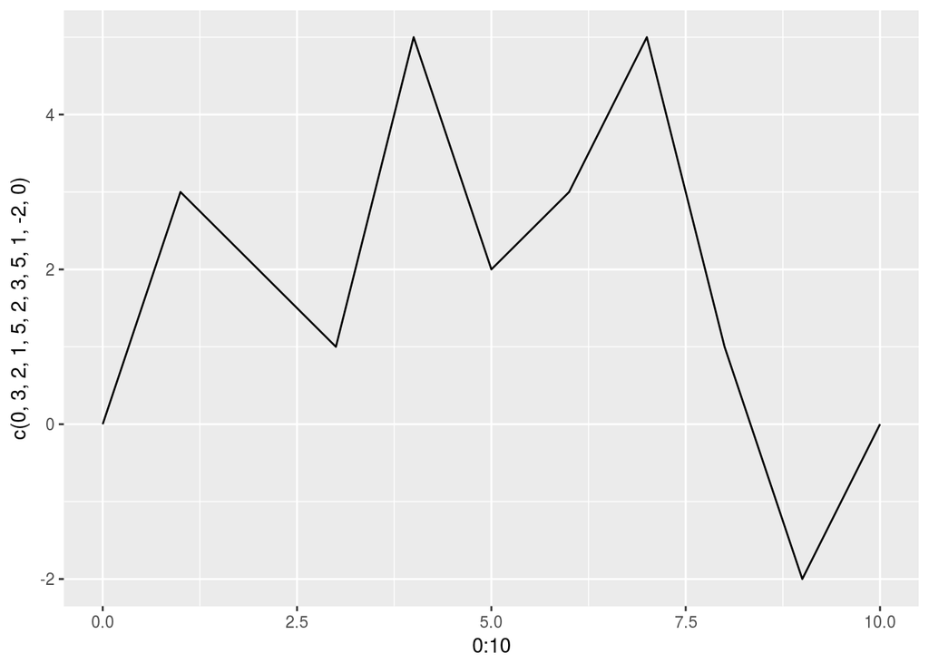

```r
ggplot() + geom_line(aes(x = 0:10, y = c(0, 3, 2, 1, 5, 2, 3, 5, 1, -2, 0)))
```

### Bar

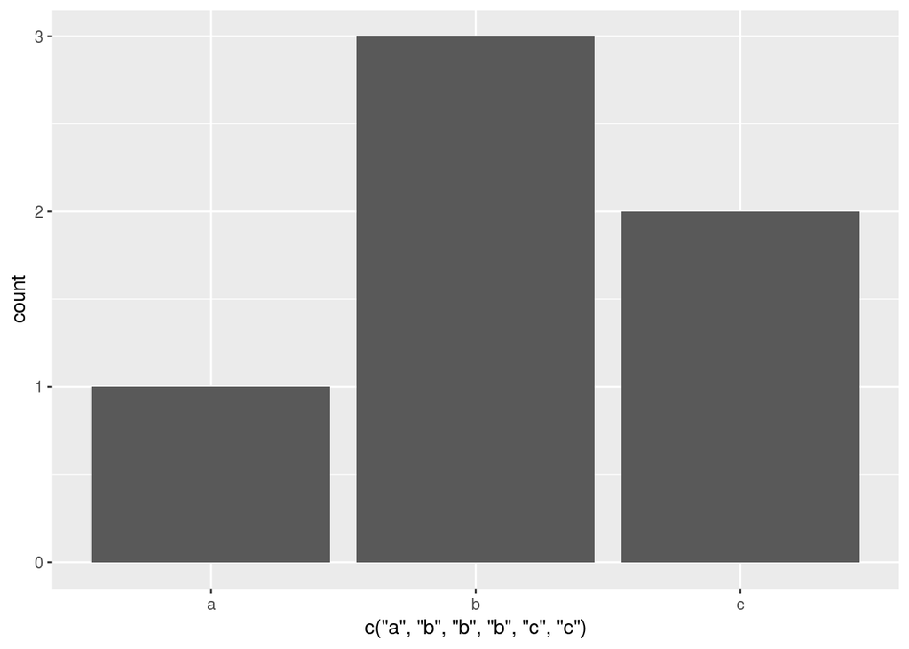

```r
ggplot() + geom_bar(aes(x = c('a', 'b', 'b', 'b', 'c', 'c')))
```

### Histogram

Like bar, for continuous variables. Bin width can be specified.

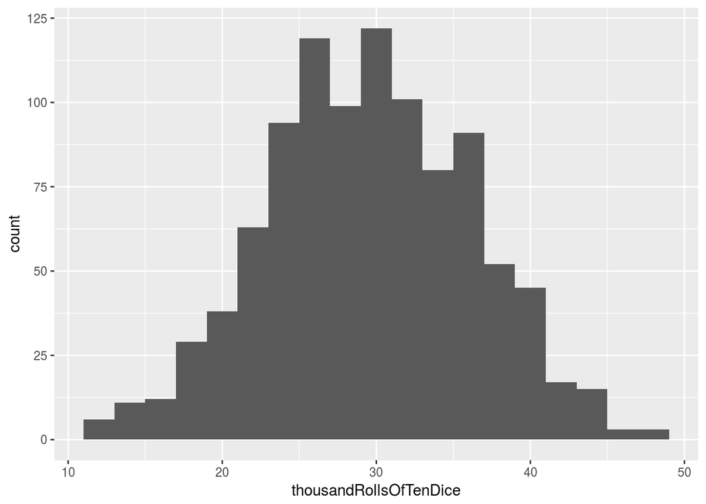

```r
thousandRollsOfTenDice = replicate(1000, sum(sample(0:6, 10, replace=TRUE)))
ggplot() + geom_histogram(binwidth=2, aes(x = thousandRollsOfTenDice))
```

## Labels

Graph labels can be changed by appending the functions:

- ggtitle
- xlab
- ylab
- labs

#### Exercise

Make a blank graph with custom labels.

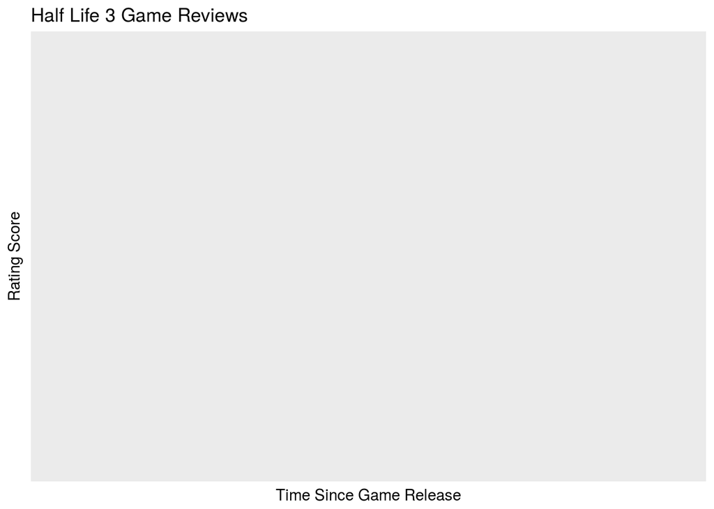

## Faceting

Sometimes you want to make multiple graphs, each representing a different aspect of your data. You could write out a function that takes in the data and the desired value to filter out the data for, or you could “facet” and let ggplot do this for you.

### Example

Let’s histogram the hours of sleep of various mammals.

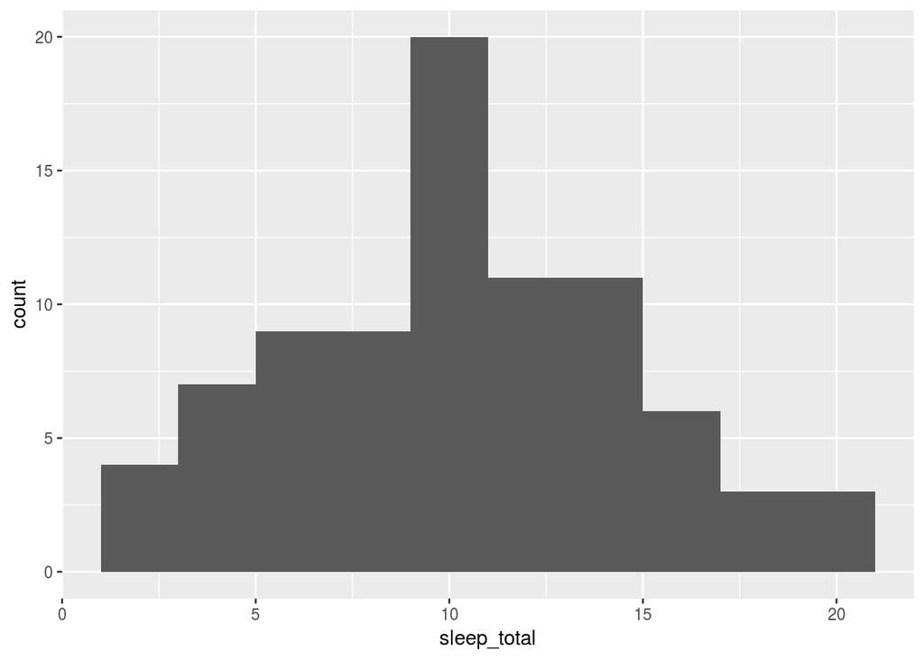

```r
# msleep is a dataset built into ggplot. When you library(ggplot2) you import this data.
ggplot(data = msleep) +
  geom_histogram(binwidth=2, aes(x = sleep_total))
```

Now let’s facet based this graph by what the mammals eat (the “vore” column of the data).

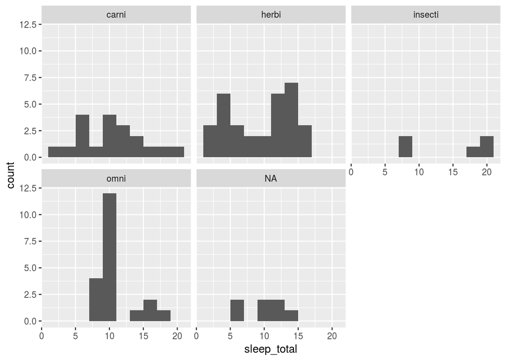

```r
# msleep is a dataset built into ggplot. When you library(ggplot2) you import this data.
ggplot(data = msleep) +
  geom_histogram(binwidth=2, aes(x = sleep_total)) +
  facet_wrap(~vore)
```

### Exercise

The ‘diamonds’ dataset is also built into ggplot. It contains pricing and sizing data of 50,000 diamonds. Columns include:

- Carat
- Cut
- Depth
- Price
- X/Y/Z (sizing info)

#### 1. Plot “x” size on X axis, Price on Y

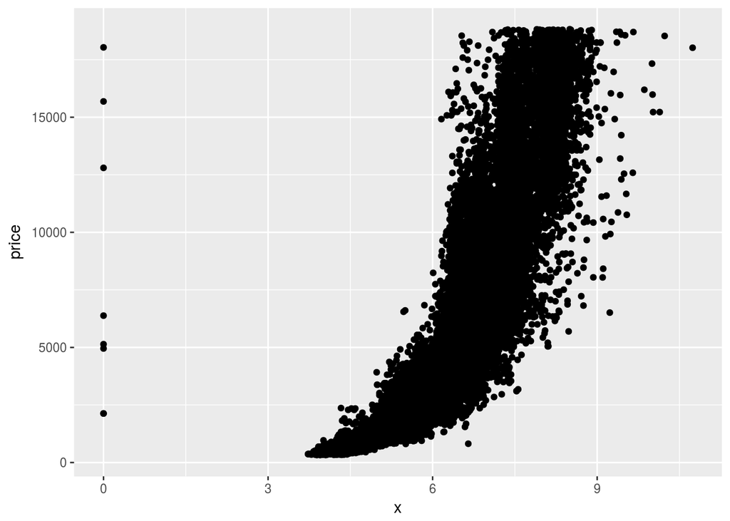

#### 2. Plot same graph as before, faceting on cut

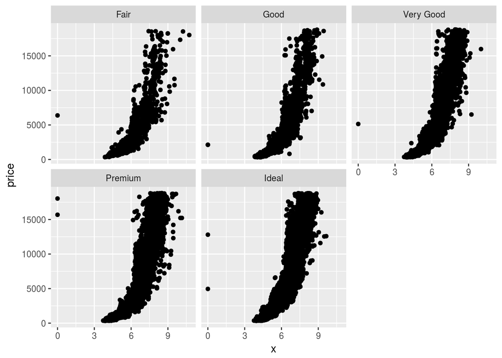

## Coloring

In addition to faceting, we can color the data based on a variable. Here’s the same mammal sleep histogram as above, but colored by diet:

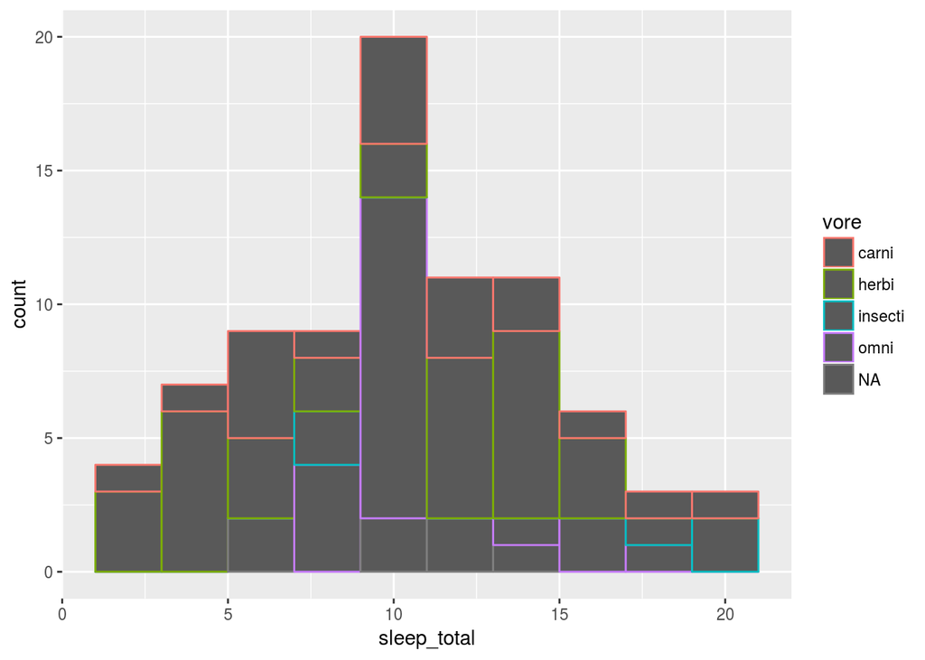

```r
# msleep is a dataset built into ggplot. When you library(ggplot2) you import this data.
ggplot(data = msleep) +
  geom_histogram(binwidth=2, aes(x = sleep_total, color = vore))
```

Note: To make the histogram fill the bars rather than outline, use the “fill” aes parameter instead.

#### Exercise

Redo the faceted diamond example, coloring based on carat. Because carat is a continuous variable, it will use a gradient rather than a distinct palatte.

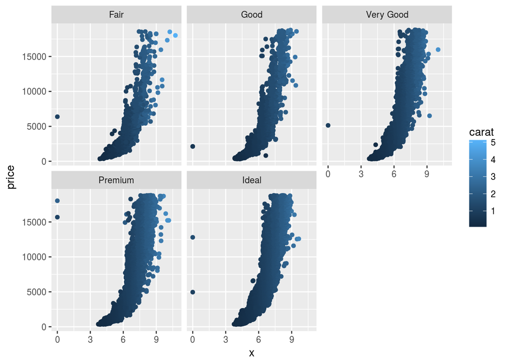